# AI Algorithms II, Week 2 Coding Homework

## Steven VanOmmeren

```python
import pandas as pd
import numpy as np
import matplotlib.pyplot as plt
import seaborn as sns
import random, time
```

```python
# Read the csv file
df = pd.read_csv('Fish.csv')
```

## Note on Species variable

The instructions of this assignment say to use the categorical variable Species, but the instructions also saythat we should have six control variables.

Normally, I would convert each value of Species into a separate dummy variable, which would result in 11 control variables (omitting one category to avoid collinearity). But to align with the instructions, I am going to encode the values of species to integers based on alphabetical order.

# Data Processing

We apply the following steps to prepare the data:

- convert Species to a numerical variable
- apply a min-max function to restrict all variables to [0, 1]
- separate the data into X and Y data sets
- split into training and testing sets using an 80% random sample of the data for training

```python
# Data Processing

# Turn "Species" into an integer based on alphabetical order of the unique values
df['Species'] = df['Species'].astype('category').cat.codes

# Apply min-max formula to rescale columns to [0, 1]
df = (df - df.min()) / (df.max() - df.min())

# Separate out the X and Y variables.
Y = df['Weight']
X = df.drop('Weight', axis=1)

# Set aside a test and train dataset.
df_train = df.sample(frac=0.8, random_state=1234)
df_test  = df.drop(df_train.index)
X_train  = df_train.drop('Weight', axis=1)
X_test   = df_test.drop('Weight', axis=1)
Y_train  = df_train['Weight']
Y_test   = df_test['Weight']
```

```python
df.sample(frac=1, random_state=1234).head(10)
```

|  | Species | Weight | Length1 | Length2 | Length3 | Height | Width |
| --- | --- | --- | --- | --- | --- | --- | --- |
| 94 | 0.333333 | 0.090909 | 0.262136 | 0.265455 | 0.265203 | 0.202576 | 0.363442 |
| 27 | 0.000000 | 0.432727 | 0.489320 | 0.501818 | 0.552365 | 0.858375 | 0.677140 |
| 57 | 1.000000 | 0.185455 | 0.351456 | 0.356364 | 0.371622 | 0.409180 | 0.512235 |
| 132 | 0.500000 | 0.260606 | 0.543689 | 0.538182 | 0.535473 | 0.322812 | 0.497421 |
| 73 | 0.333333 | 0.019394 | 0.097087 | 0.096364 | 0.099662 | 0.104454 | 0.134134 |
| 121 | 0.333333 | 0.615152 | 0.572816 | 0.574545 | 0.567568 | 0.618297 | 0.904206 |
| 74 | 0.333333 | 0.024242 | 0.122330 | 0.120000 | 0.121622 | 0.121635 | 0.195140 |
| 150 | 0.833333 | 0.005273 | 0.064078 | 0.052727 | 0.064189 | 0.014499 | 0.033491 |
| 39 | 0.666667 | 0.072727 | 0.215534 | 0.210909 | 0.226351 | 0.260474 | 0.356140 |
| 6 | 0.000000 | 0.303030 | 0.374757 | 0.387273 | 0.434122 | 0.722699 | 0.596372 |

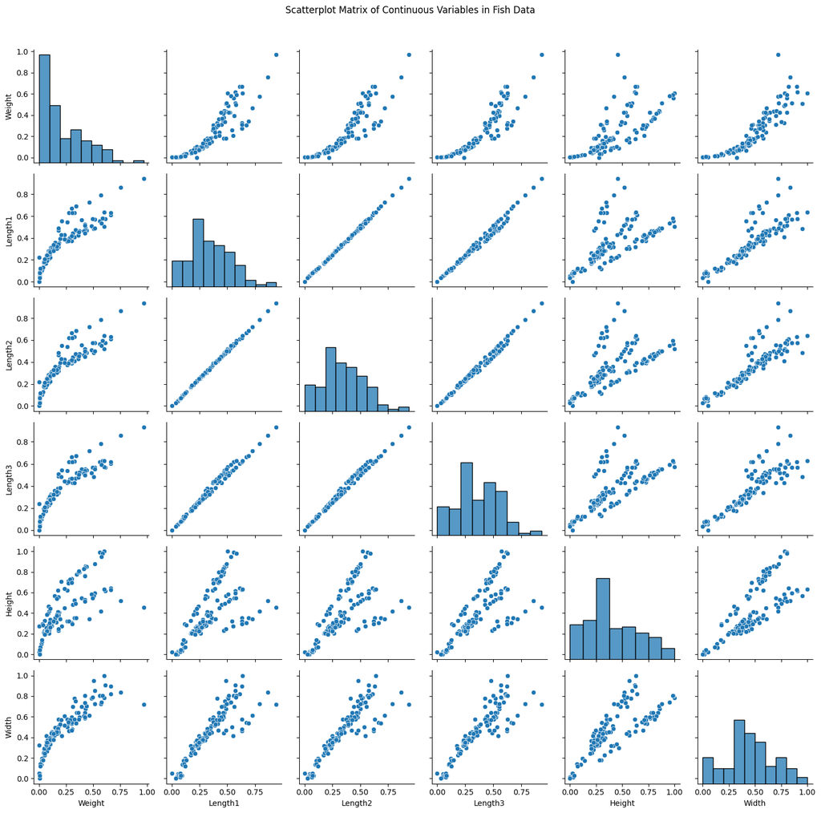

```python
# Report scatterplot matrix of the continuous variables
sns.pairplot(df_train[['Weight', 'Length1', 'Length2', 'Length3', 'Height', 'Width']])
plt.suptitle('Scatterplot Matrix of Continuous Variables in Fish Data', y=0.98)
plt.tight_layout(rect=[0, 0, 1, 0.96])
plt.show()
```

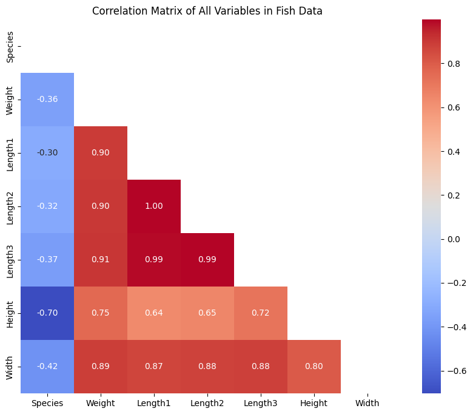

```python
# Report a correlation matrix of all fields
plt.figure(figsize=(12, 8))
mask = np.triu(np.ones_like(df_train.corr(), dtype=bool))
sns.heatmap(df_train.corr(), annot=True, fmt=".2f", cmap='coolwarm', square=True, mask=mask)
plt.title('Correlation Matrix of All Variables in Fish Data')
plt.show()
```

The scatterplot matrix and correlation matrix both show that some variables are highly correlated (e.g. the different length fields), suggesting a potential for multicollinearity.

```python
# define some helper functions
def initialize_params(seed=1234):
    random.seed(seed)
    w = [random.uniform(-1,1) for _ in range(X_train.shape[1])]
    b = random.uniform(-1,1)
    a = random.uniform(0,.1) # learning rate
    n = 50000 # number of gradient descent steps
    m = X_train.shape[0] # number of rows
    J = X_train.shape[1] # number of columns
    cost_history = [] # loss function history
    return w,b,a,n,m,J,cost_history

def predict(x_i,w,b):
    z = [x_i[i]*w[i] for i in range(len(x_i))] # dot product using lists
    return(sum(z)+b)

def predict_vec(x,w,b):
    return(x@w + b) # matrix multiplication
```

```python
# calculating gradient descent with for loops algorithm
w,b,a,n,m,J,cost_history = initialize_params()
y = Y_train.to_list()

t0 = time.time()
for k in range(n):
	y_hat,resid,resid2=[],[],[]
	residx=[[] for _ in range(J)] # Create J separate empty lists

	for i in range(m):
		x_i = X_train.iloc[i,:].to_list()

		y_hat.append(predict(x_i,w,b)) # make predictions with existing params
		resid.append(y_hat[i] - y[i]) # calculate residuals
		resid2.append(resid[i]**2) # residuals squared

		for j in range(J):
			residx[j].append(resid[i] * x_i[j]) # calculate residual times x_j

	b = b - (a/m * sum(resid[:])) # gradient descent for constant term

	for j in range(J):
		w[j] = w[j] - (a/m * sum(residx[j])) # gradient descent for each control var

	cost = 1/(2*m) * sum(resid2) # calculate total cost
	if k%10000==0: print(f'Iteration {k}: Total Cost: {cost:0.6f}.')

	cost_history.append(cost)

time_for_loop_algo = time.time() - t0 # Time to run
cost_history_for_loop = cost_history # Save cost history for comparison
print(f'Final cost (for loop algo): {cost_history[-1]:0.6f}.')
```

```
Iteration 0: Total Cost: 0.365543.
Iteration 10000: Total Cost: 0.003340.
Iteration 20000: Total Cost: 0.002706.
Iteration 30000: Total Cost: 0.002598.
Iteration 40000: Total Cost: 0.002570.
Final cost (for loop algo): 0.002558.
```

```python
# calculating gradient descent with vectorized algorithm
w,b,a,n,m,J,cost_history = initialize_params()
w = np.array(w) # convert w to numpy array
b = np.array(b) # convert b to numpy array

t0 = time.time()
for k in range(n):
    y_hat = predict_vec(X_train,w,b) # make predictions with existing params
    b = b - (a/m * np.sum(y_hat - Y_train))
    w = w - (a/m * X_train.T @ (y_hat - Y_train))
    cost = 1/(2*m) * (y_hat - Y_train).T @ (y_hat - Y_train) # calculate total cost
    if k%10000==0: print(f'Iteration {k}: Total Cost: {cost:0.6f}.')

    cost_history.append(cost)

time_vec_algo = time.time() - t0 # Time to run
cost_history_vec = cost_history # Save cost history for comparison
print(f'Final cost (vectorized algo): {cost_history[-1]:0.6f}.')
```

```
Iteration 0: Total Cost: 0.365543.
Iteration 10000: Total Cost: 0.003340.
Iteration 20000: Total Cost: 0.002706.
Iteration 30000: Total Cost: 0.002598.
Iteration 40000: Total Cost: 0.002570.
Final cost (vectorized algo): 0.002558.
```

```python
# Compare time to run
print(f'Average time per iteration (for loop): {time_for_loop_algo/n*1000:.2f} ms.')
print(f'Average time per iteration (vectorized): {time_vec_algo/n*1000:.2f} ms.')
print(f'Vectorized speed-up over for loop algo: {time_for_loop_algo/time_vec_algo:.2f}x')
```

```
Average time per iteration (for loop): 4.94 ms.
Average time per iteration (vectorized): 0.69 ms.
Vectorized speed-up over for loop algo: 7.17x
```

```python
# Question: what is the cost when using a standard OLS library?
from sklearn.linear_model import LinearRegression
model=LinearRegression()
model.fit(X_train, Y_train)

# compute cost function on actual predictions
resid = (model.predict(X_train) - Y_train)**2
ideal_cost = resid.sum() / (2*Y_train.shape[0])
```

```python
# Compare ideal cost to final cost from both algorithms
print(f'Final cost (for loop algo): {cost_history_for_loop[-1]:0.6f}.')
print(f'Final cost (vectorized algo): {cost_history_vec[-1]:0.6f}.')
print(f'Ideal cost: {ideal_cost:.6f}')
```

```
Final cost (for loop algo): 0.002558.
Final cost (vectorized algo): 0.002558.
Ideal cost: 0.002205
```

After 50,000 steps of gradient descent, our algorithm has a total cost function that is 16% higher than the ideal cost from a standard OLS library. Choosing a different learning rate and increasing the number of steps could improve this result. Ideally we would use a learning rate schedule so that we don't have to waste computation going through the "easier" parts of the optimization; we would start with a larger learning rate and then gradually decrease it over time.